# Econometrics 2 capstone final report data code

Josh Copeland, Jocelyn Koswara and Ryan Luo

2024-10-1

# Importing and cleaning data

Tables used for the progress report:

- Psychology (S10AI)
- Housing: water (S12AI)
- Household background information (S1D)
- Key household information (key_hhld_info)

Analysis in this markdown document is separated by each data table imported.

### Importing the Pyschology table

```r
################################################################################
################################ PSYCHOLOGY TABLE ##############################
################################################################################

s10ai <- read_csv("data/S10AI.csv") %>%
  select(hhno, hhmid, depression, sex = s1d_1, age = s1d_4i) %>%

  #Creating a new column as our depression_dummy. Kessler scores between 10-19 have a score of one in the data (== "likely to be well"). Anyone with scored higher than this has a score > 1, which classifies them as likely to have at least a mild disorder.
  mutate(depression_dummy = case_when(

    depression > 1 ~ 1, # Depressed
    TRUE ~ 0 # Not depressed

  )) %>%

  # Turning sex into a dummy variable (1 == female)

  mutate(sex = case_when(

    sex == 1 ~ 0,
    sex == 2 ~ 1

  ))


######################## EXTRACTING JUST THE RELEVANT VARIABLES ################

s10ai <- s10ai %>%
  select(hhno, hhmid, depression_dummy, sex_dummy = sex, age)
```

### Importing the housing table

We are importing this table to create a dummy variable for access to basic drinking services.

UNICEF defines a household’s access to water as “basic” if it satisfies the following conditions:

- It’s delivered from one of the following sources: piped water, boreholes, tubewells, protected dug well, protected springs, rainwater and packaged of delivered water.
- A round trip to collect water does not exceed 30 minutes.

UNICEF actually has different definitions for water access, where we want to capture dummies for them as one of our extensions. They are defined as:

- Safely managed: Drinking water from an improved water souce which is located on premises, available when needed and free of faecal and priority contamination.
- Basic: as defined above.
- No services: drinking water collected directly fro ma river, dam, lake, pond, stream, canal or irrigation channel.

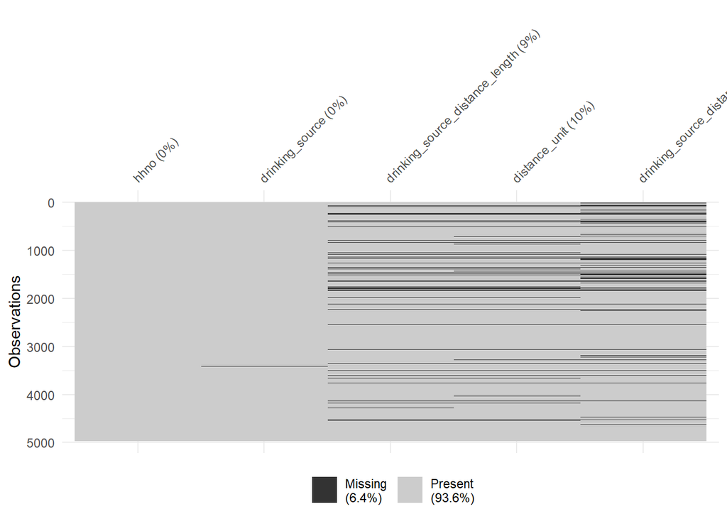

```r
################################################################################
############################### HOUSING TABLES #################################
################################################################################

############################### WATER TABLE ####################################







s12ai <- read_csv("data/S12AI.csv") %>%
  select(hhno,drinking_source = s12a_9i, drinking_source_distance_length = s12a_10ai, distance_unit = s12a_10aii, drinking_source_distance_mins = s12a_11) %>%

  #Editing the drinking_source_distance cells to make them all the same scale: kilometres.

  mutate(drinking_source_distance_length = case_when(

    distance_unit == 0 ~ 0,  # In house
    distance_unit == 1 ~ as.numeric(drinking_source_distance_length) * 0.0009144,  # Yards to kilometers
    distance_unit == 2 ~ as.numeric(drinking_source_distance_length) / 1000,  # Meters to kilometers
    distance_unit == 3 ~ as.numeric(drinking_source_distance_length),  # Already in kilometers
    distance_unit == 4 ~ as.numeric(drinking_source_distance_length) * 1.609344,  # Miles to kilometers
    TRUE ~ drinking_source_distance_length

  ))
vis_miss(s12ai)
```

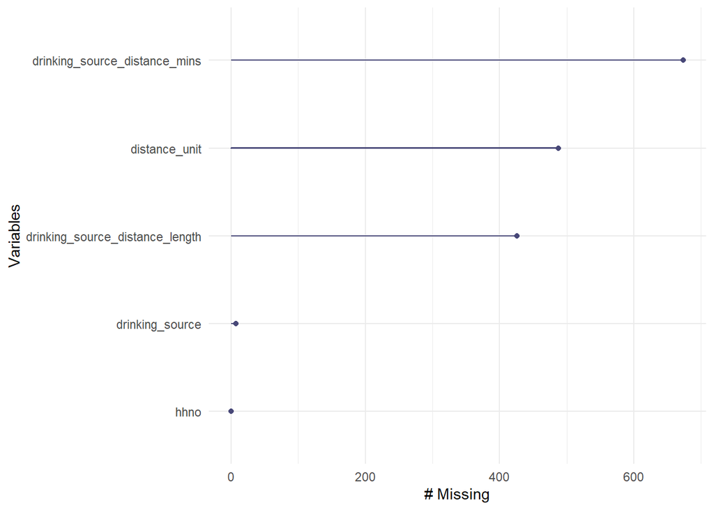

```r
gg_miss_var(s12ai)
```

The charts above shows us that there is a lot of missing values for the distance variables in both length and mins. This likely have something todo with the drinking source of each household. I need to collect all the NA data together in order to diagnose the problem.

The charts below show us that:

- Most of the problem is in 1 and 2, which correspond to plumbing in the house. We can change their distances to zero.
- 8 is also a clear problem, which is bottled water. We think its reasonable to assume this botteld water is available at the house, so can change this distance to zero as well.
- 9 and 10 are protected wells and boreholes. Without more information about how far away they are (unavailable) we need to leave these as NAs.

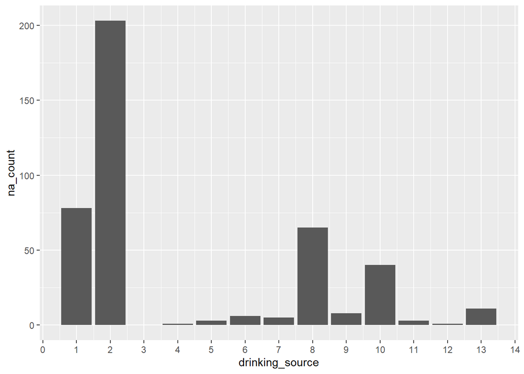

```r
# Extracting and charting NA data

na_data <- s12ai %>%
  filter(is.na(drinking_source_distance_length)) %>%
  group_by(drinking_source) %>%
  summarise(na_count = n())

ggplot(na_data, aes(x = drinking_source, y = na_count)) +
  geom_bar(stat = "identity") +
  scale_x_continuous(breaks = scales::pretty_breaks(n = 14))
```

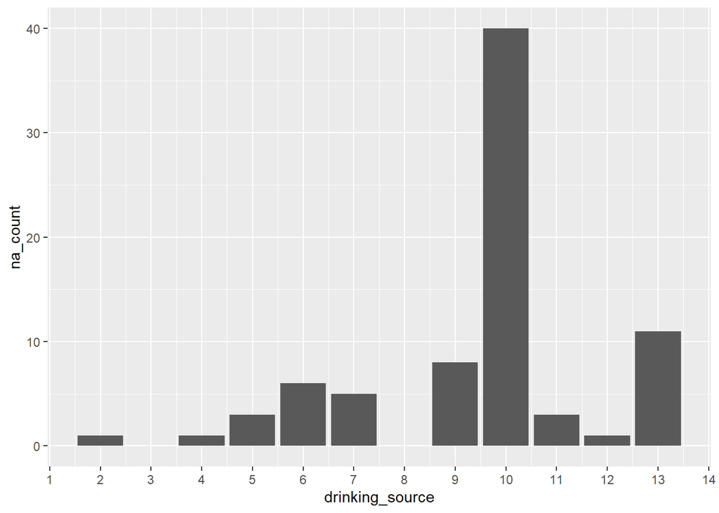

```r
# Now I have diagnosed the problem, I need to make the necessary changes to the dataframe such that dirnking_sources with values 1 and 2 have a distance of zero in both length and minutes. All other NAs remain given data limitations.

s12ai <- s12ai %>%
  mutate(drinking_source_distance_length = case_when(

    is.na(distance_unit) & drinking_source %in% c(1, 2, 8) ~ 0,
    TRUE ~ drinking_source_distance_length
  )) %>%

  mutate(drinking_source_distance_mins = case_when(
        is.na(distance_unit) & drinking_source %in% c(1, 2, 8) ~ 0,
    TRUE ~ drinking_source_distance_mins
  ))



# Repeating the NA value analysis/chart below, the scale are now sufficiently small to continue/we don't have any other information that could help reduce the incidence of NAs.

na_data <- s12ai %>%
  filter(is.na(drinking_source_distance_length)) %>%
  group_by(drinking_source) %>%
  summarise(na_count = n())

ggplot(na_data, aes(x = drinking_source, y = na_count)) +
  geom_bar(stat = "identity") +
  scale_x_continuous(breaks = scales::pretty_breaks(n = 14))
```

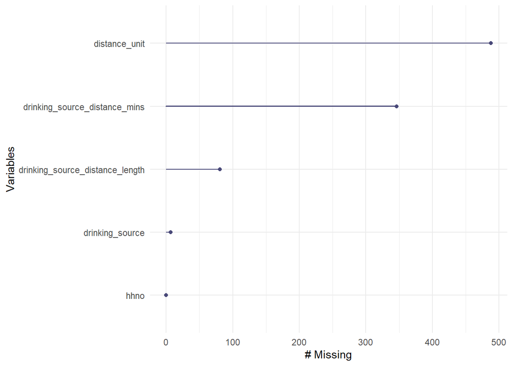

```r
gg_miss_var(s12ai)
```

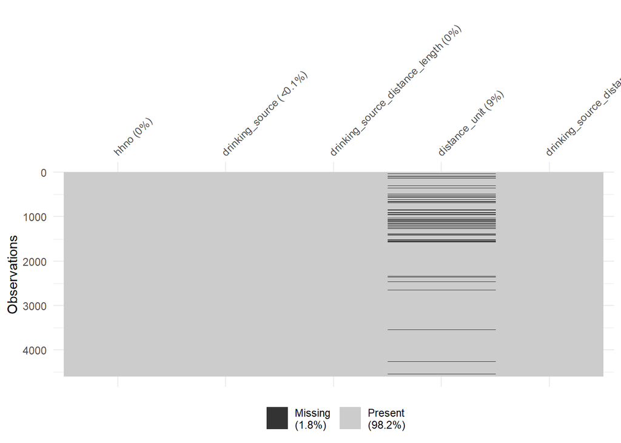

```r
# Because we can't deal with the remaining NAs, we exclude them from our analysis. However, we only exclude where NAs appear in the drinking_source_distance_length and drinking_source_distance_mins  variables.

s12ai <- s12ai %>%
  filter(!is.na(drinking_source_distance_length)) %>%
  filter(!is.na(drinking_source_distance_mins))

vis_miss(s12ai)
```

Now we can actually produce our dummy variable for access to “basic drinking services”.

```r
s12ai <- s12ai %>%

  # Basic access

  mutate(

    basic_access_dummy = case_when(

      drinking_source_distance_mins <= 30 &
      drinking_source %in% c(1, # Indoor plumbing
                             2, # Inside standpipe
                             5, # Pipe in niehgbouring household
                             6, # Private outside standpipe/tap
                             7, # Public standpipe
                             8, # Sachet/bottled water
                             9, # Borehole
                             10) # Protected well
    ~ 1,
    TRUE ~ 0
  )) %>%

  # Safely managed

  mutate(

    safely_managed_dummy = case_when(

            drinking_source_distance_mins <= 2 &
            drinking_source %in% c(1, # Indoor plumbing
                             2, # Inside standpipe
                             5, # Pipe in niehgbouring household
                             6, # Private outside standpipe/tap
                             7, # Public standpipe
                             8, # Sachet/bottled water
                             9, # Borehole
                             10) # Protected well
        ~ 1,
        TRUE ~ 0
            )) %>%

  # No service

  mutate(no_service_dummy = case_when(

    drinking_source %in% c(12, # River/Stream
                           14) #Dugout/ponk/lake/dam

           ~ 1,
       TRUE ~ 0
  ))
```

# Importing the hosehold background information table

```r
######################### RELIGIOUS MINORITY DUMMY #############################


s1d <- read_csv("data/S1D.csv") %>%
  select(hhno, hhmid, religion = s1d_13, ethnicity = s1d_16) %>%
  mutate(not_christian_dummy = 0) %>%
  mutate(not_christian_dummy = case_when(

    # The following values of religion correspond with Christianity: 1,2,3,4,5 and 7.

    religion %in% c(1,2,3,4,5,7) ~ 0,
    TRUE ~ 1

  ))
```

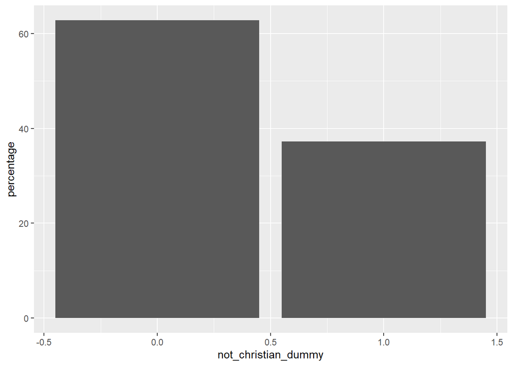

```r
# Is it reasonable to think of Christian as the relgious majority? The chart below suggest they account for ~ 60% of the population. Therefore, it's reasonable to account for non-Christians are part of the relgious minority in Ghana.

religion_dummy_frequency <- s1d %>%
  group_by(not_christian_dummy) %>%
    summarise(count = n()) %>%
  mutate(percentage = (count / sum(count)) * 100)



ggplot(religion_dummy_frequency, aes(not_christian_dummy, percentage)) + geom_bar(stat = "identity")
```

```r
######################## EXTRACTING JUST THE RELEVANT VARIABLES ################

s1d <- s1d %>%
  select(hhno, hhmid, not_christian_dummy)
```

# Importing key household information

```r
key_hhld_info <- read_csv("data/key_hhld_info.csv") %>%
  select(hhno, rural_dummy = urbrur) %>%
  mutate(rural_dummy = case_when(

    rural_dummy == "1" ~ 0,
    TRUE ~ 1

  ))
```

# Joining data

Household data is not provided at the individual level. Therefore, we need to append it to our psychological data.

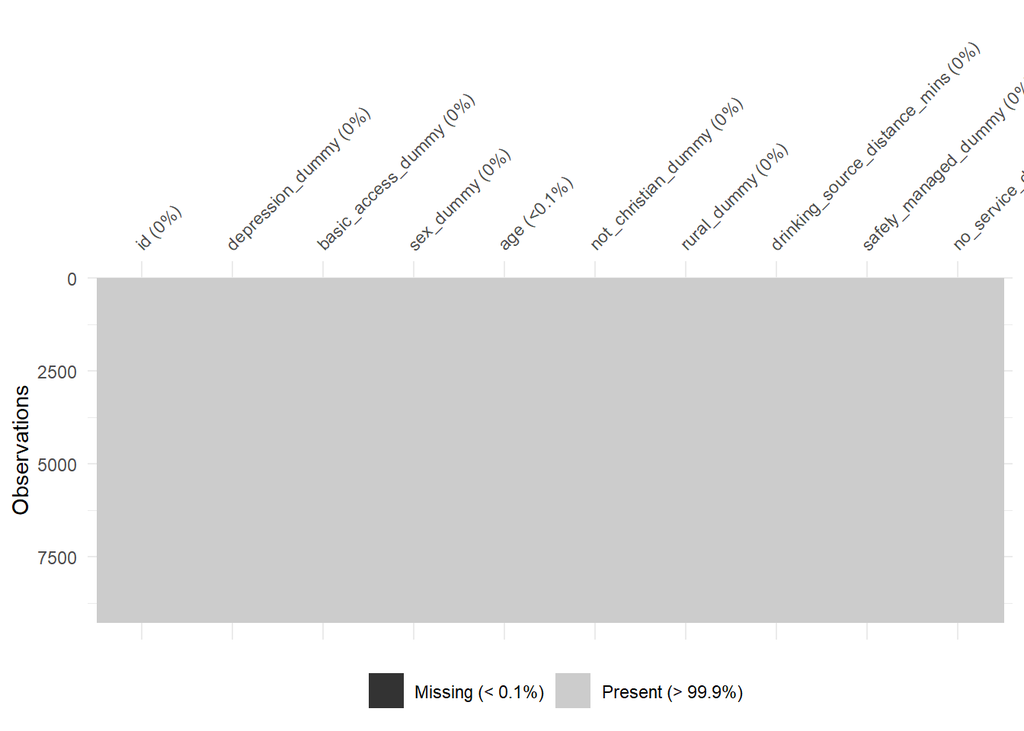

```r
data <- s10ai %>%
  inner_join(s12ai, by = "hhno") %>%
  inner_join(key_hhld_info, by = "hhno") %>%
  inner_join(s1d, by = c("hhno", "hhmid")) %>%  # This data is collected on the individual, therefore we need to join at the sub-household level.

  mutate(id = hhno + hhmid) %>%  # Creating a single hh identifier column

  select(id, depression_dummy, basic_access_dummy, sex_dummy, age, not_christian_dummy, rural_dummy, drinking_source_distance_mins, safely_managed_dummy, no_service_dummy) #getting data columns into a helpful order

vis_miss(data)
```

```r
# Omitting the very few remaining NA values

data <- data %>%
  na.omit()
```

# Creating summary statistics

```r
vars <- colnames(data)[!colnames(data) %in% c("id")]

# Create summary statistics
summary_stats <- data %>%
  summarise(across(all_of(vars),
                   list(
                     mean = ~ mean(.x, na.rm = TRUE),
                     sd = ~ sd(.x, na.rm = TRUE),
                     min = ~ min(.x, na.rm = TRUE),
                     max = ~ max(.x, na.rm = TRUE)
                   ),
                   .names = "{.col}_{.fn}"))

# Reshape to long format
summary_stats <- summary_stats %>%
  pivot_longer(cols = everything(),
               names_to = c("variable", "statistic"),
               names_pattern = "(.*)_(.*)") %>%   # Match everything before the last underscore
  mutate(value = round(value,2))


summary_stats <- summary_stats %>%
  pivot_wider(names_from = statistic, values_from = value)

summary_stats$max <- format(summary_stats$max, scientific = FALSE)


print(summary_stats)
```

```
## # A tibble: 9 × 5
##   variable                       mean    sd   min max
##   <chr>                         <dbl> <dbl> <dbl> <chr>
## 1 depression_dummy               0.31  0.46     0 "  1"
## 2 basic_access_dummy             0.76  0.43     0 "  1"
## 3 sex_dummy                      0.55  0.5      0 "  1"
## 4 age                           39.1  18.7      1 "109"
## 5 not_christian_dummy            0.34  0.47     0 "  1"
## 6 rural_dummy                    0.65  0.48     0 "  1"
## 7 drinking_source_distance_mins 15.6  18.0      0 "240"
## 8 safely_managed_dummy           0.12  0.33     0 "  1"
## 9 no_service_dummy               0.15  0.35     0 "  1"
```

```r
#################################### SAVING OFF DATA ###########################

write_csv(summary_stats, "summary_stats.csv")

write_csv(data, "model_data.csv")
```

# Producing model outputs

```r
data <- read_csv("model_data.csv")
```

# Key models/output

```r
#################################### MODELS ####################################

# linear regression model
m1 <- lm(depression_dummy ~ basic_access_dummy, data = data)


# Multiple linear regresion model
m2 <- lm(depression_dummy ~ basic_access_dummy + sex_dummy + age + not_christian_dummy + rural_dummy, data = data)


# First stage 2SLS model
m3 <- lm(basic_access_dummy ~ drinking_source_distance_mins + sex_dummy + age + not_christian_dummy + rural_dummy,
                  data = data)

# Second stage 2SLS model
m4 <- ivreg(depression_dummy ~ basic_access_dummy + sex_dummy + age + not_christian_dummy + rural_dummy |
      sex_dummy + age + not_christian_dummy + rural_dummy + drinking_source_distance_mins, data = data)

summary(m4, vcov=vcovHC, diagnostics = TRUE)
```

```
##
## Call:
## ivreg(formula = depression_dummy ~ basic_access_dummy + sex_dummy +
##     age + not_christian_dummy + rural_dummy | sex_dummy + age +
##     not_christian_dummy + rural_dummy + drinking_source_distance_mins,
##     data = data)
##
## Residuals:
##     Min      1Q  Median      3Q     Max
## -0.7651 -0.3145 -0.1899  0.4967  0.9777
##
## Coefficients:
##                       Estimate Std. Error t value Pr(>|t|)
## (Intercept)          0.2200668  0.0294799   7.465 9.08e-14 ***
## basic_access_dummy  -0.2208962  0.0280809  -7.866 4.06e-15 ***
## sex_dummy            0.0861642  0.0093199   9.245  < 2e-16 ***
## age                  0.0038505  0.0002521  15.273  < 2e-16 ***
## not_christian_dummy  0.0833770  0.0108167   7.708 1.41e-14 ***
## rural_dummy          0.0443765  0.0115649   3.837 0.000125 ***
##
## Diagnostic tests:
##                   df1  df2 statistic  p-value
## Weak instruments    1 9276    354.29  < 2e-16 ***
## Wu-Hausman          1 9275     30.37 3.67e-08 ***
## Sargan              0   NA        NA       NA
## ---
## Signif. codes:  0 '***' 0.001 '**' 0.01 '*' 0.05 '.' 0.1 ' ' 1
##
## Residual standard error: 0.4494 on 9276 degrees of freedom
## Multiple R-Squared: 0.05307, Adjusted R-squared: 0.05256
## Wald test: 133.4 on 5 and 9276 DF,  p-value: < 2.2e-16
```

# Formatting output

```r
#################################### OUTPUT TABLES ##############################


key_results <- stargazer(m1,
                         m2,
                         m3,
                         m4,
                         type = "html",
                         title = "Table 2: Model estimates",
                           se = list(
                          sqrt(diag(vcovHC(m1))),
                          sqrt(diag(vcovHC(m2))),
                          sqrt(diag(vcovHC(m3))),
                          sqrt(diag(vcovHC(m4)))
                          ),
                        out = "Key_Results.html"

  )
```

```
##
## <table style="text-align:center"><caption><strong>Table 2: Model estimates</strong></caption>
## <tr><td colspan="5" style="border-bottom: 1px solid black"></td></tr><tr><td style="text-align:left"></td><td colspan="4"><em>Dependent variable:</em></td></tr>
## <tr><td></td><td colspan="4" style="border-bottom: 1px solid black"></td></tr>
## <tr><td style="text-align:left"></td><td colspan="2">depression_dummy</td><td>basic_access_dummy</td><td>depression_dummy</td></tr>
## <tr><td style="text-align:left"></td><td colspan="2"><em>OLS</em></td><td><em>OLS</em></td><td><em>instrumental</em></td></tr>
## <tr><td style="text-align:left"></td><td colspan="2"><em></em></td><td><em></em></td><td><em>variable</em></td></tr>
## <tr><td style="text-align:left"></td><td>(1)</td><td>(2)</td><td>(3)</td><td>(4)</td></tr>
## <tr><td colspan="5" style="border-bottom: 1px solid black"></td></tr><tr><td style="text-align:left">basic_access_dummy</td><td>-0.134<sup>***</sup></td><td>-0.093<sup>***</sup></td><td></td><td>-0.221<sup>***</sup></td></tr>
## <tr><td style="text-align:left"></td><td>(0.012)</td><td>(0.012)</td><td></td><td>(0.028)</td></tr>
## <tr><td style="text-align:left"></td><td></td><td></td><td></td><td></td></tr>
## <tr><td style="text-align:left">drinking_source_distance_mins</td><td></td><td></td><td>-0.010<sup>***</sup></td><td></td></tr>
## <tr><td style="text-align:left"></td><td></td><td></td><td>(0.001)</td><td></td></tr>
## <tr><td style="text-align:left"></td><td></td><td></td><td></td><td></td></tr>
## <tr><td style="text-align:left">sex_dummy</td><td></td><td>0.086<sup>***</sup></td><td>0.007</td><td>0.086<sup>***</sup></td></tr>
## <tr><td style="text-align:left"></td><td></td><td>(0.009)</td><td>(0.008)</td><td>(0.009)</td></tr>
## <tr><td style="text-align:left"></td><td></td><td></td><td></td><td></td></tr>
## <tr><td style="text-align:left">age</td><td></td><td>0.004<sup>***</sup></td><td>-0.0002</td><td>0.004<sup>***</sup></td></tr>
## <tr><td style="text-align:left"></td><td></td><td>(0.0002)</td><td>(0.0002)</td><td>(0.0003)</td></tr>
## <tr><td style="text-align:left"></td><td></td><td></td><td></td><td></td></tr>
## <tr><td style="text-align:left">not_christian_dummy</td><td></td><td>0.099<sup>***</sup></td><td>-0.039<sup>***</sup></td><td>0.083<sup>***</sup></td></tr>
## <tr><td style="text-align:left"></td><td></td><td>(0.010)</td><td>(0.009)</td><td>(0.011)</td></tr>
## <tr><td style="text-align:left"></td><td></td><td></td><td></td><td></td></tr>
## <tr><td style="text-align:left">rural_dummy</td><td></td><td>0.074<sup>***</sup></td><td>-0.140<sup>***</sup></td><td>0.044<sup>***</sup></td></tr>
## <tr><td style="text-align:left"></td><td></td><td>(0.010)</td><td>(0.008)</td><td>(0.012)</td></tr>
## <tr><td style="text-align:left"></td><td></td><td></td><td></td><td></td></tr>
## <tr><td style="text-align:left">Constant</td><td>0.409<sup>***</sup></td><td>0.100<sup>***</sup></td><td>1.031<sup>***</sup></td><td>0.220<sup>***</sup></td></tr>
## <tr><td style="text-align:left"></td><td>(0.010)</td><td>(0.017)</td><td>(0.011)</td><td>(0.029)</td></tr>
## <tr><td style="text-align:left"></td><td></td><td></td><td></td><td></td></tr>
## <tr><td colspan="5" style="border-bottom: 1px solid black"></td></tr><tr><td style="text-align:left">Observations</td><td>9,282</td><td>9,282</td><td>9,282</td><td>9,282</td></tr>
## <tr><td style="text-align:left">R<sup>2</sup></td><td>0.015</td><td>0.066</td><td>0.266</td><td>0.053</td></tr>
## <tr><td style="text-align:left">Adjusted R<sup>2</sup></td><td>0.015</td><td>0.065</td><td>0.266</td><td>0.053</td></tr>
## <tr><td style="text-align:left">Residual Std. Error</td><td>0.458 (df = 9280)</td><td>0.446 (df = 9276)</td><td>0.367 (df = 9276)</td><td>0.449 (df = 9276)</td></tr>
## <tr><td style="text-align:left">F Statistic</td><td>145.179<sup>***</sup> (df = 1; 9280)</td><td>130.714<sup>***</sup> (df = 5; 9276)</td><td>672.072<sup>***</sup> (df = 5; 9276)</td><td></td></tr>
## <tr><td colspan="5" style="border-bottom: 1px solid black"></td></tr><tr><td style="text-align:left"><em>Note:</em></td><td colspan="4" style="text-align:right"><sup>*</sup>p<0.1; <sup>**</sup>p<0.05; <sup>***</sup>p<0.01</td></tr>
## </table>
```

```r
key_results <- stargazer(m1,
                         m2,
                         m3,
                         m4,
                         type = "text",
                         title = "Table 2: Model estimates",
                           se = list(
                          sqrt(diag(vcovHC(m1))),
                          sqrt(diag(vcovHC(m2))),
                          sqrt(diag(vcovHC(m3))),
                          sqrt(diag(vcovHC(m4)))
                          )  )
```

```
##
## Table 2: Model estimates
## =============================================================================================================================
##                                                                     Dependent variable:
##                               -----------------------------------------------------------------------------------------------
##                                                depression_dummy                      basic_access_dummy     depression_dummy
##                                                       OLS                                    OLS              instrumental
##                                                                                                                 variable
##                                          (1)                       (2)                       (3)                   (4)
## -----------------------------------------------------------------------------------------------------------------------------
## basic_access_dummy                    -0.134***                 -0.093***                                       -0.221***
##                                        (0.012)                   (0.012)                                         (0.028)
##
## drinking_source_distance_mins                                                             -0.010***
##                                                                                            (0.001)
##
## sex_dummy                                                       0.086***                    0.007               0.086***
##                                                                  (0.009)                   (0.008)               (0.009)
##
## age                                                             0.004***                   -0.0002              0.004***
##                                                                 (0.0002)                  (0.0002)              (0.0003)
##
## not_christian_dummy                                             0.099***                  -0.039***             0.083***
##                                                                  (0.010)                   (0.009)               (0.011)
##
## rural_dummy                                                     0.074***                  -0.140***             0.044***
##                                                                  (0.010)                   (0.008)               (0.012)
##
## Constant                              0.409***                  0.100***                  1.031***              0.220***
##                                        (0.010)                   (0.017)                   (0.011)               (0.029)
##
## -----------------------------------------------------------------------------------------------------------------------------
## Observations                            9,282                     9,282                     9,282                 9,282
## R2                                      0.015                     0.066                     0.266                 0.053
## Adjusted R2                             0.015                     0.065                     0.266                 0.053
## Residual Std. Error               0.458 (df = 9280)         0.446 (df = 9276)         0.367 (df = 9276)     0.449 (df = 9276)
## F Statistic                   145.179*** (df = 1; 9280) 130.714*** (df = 5; 9276) 672.072*** (df = 5; 9276)
## =============================================================================================================================
## Note:                                                                                             *p<0.1; **p<0.05; ***p<0.01
```

```r
##################### AUTOMATING OUTPUTTING TABLES TO XLSX FILE ################

key_results_table <- read_html("Key_Results.html") %>%
    html_table(fill = TRUE) %>%
    pluck(1) %>%
    filter(if_any(c(X1, X2, X3), ~ . != ""))

write_xlsx(key_results_table, "key_results_table.xlsx")
```

# Robustness checks

## Changing definitions of water access

Ultimately, our chosen definition of water access has been chosen arbitrarily from UNICEF’s taxonomy of access. If our results are robust, the size of our estimators should decrease as we move from the lowest (“no service”) to highest (“safely managed”) level of water access. The better the access, the greater an impact it should have on reducing the incidence of mental health issues.

```r
################################## CREATING MODELS #############################


#No service
m5 <- ivreg(depression_dummy ~ no_service_dummy + sex_dummy + age + not_christian_dummy + rural_dummy |
      sex_dummy + age + not_christian_dummy + rural_dummy + drinking_source_distance_mins, data = data)


# Basic access
m6 <- ivreg(depression_dummy ~ basic_access_dummy + sex_dummy + age + not_christian_dummy + rural_dummy |
      sex_dummy + age + not_christian_dummy + rural_dummy + drinking_source_distance_mins, data = data)


# Safely managed
m7 <- ivreg(depression_dummy ~ safely_managed_dummy + sex_dummy + age + not_christian_dummy + rural_dummy |
      sex_dummy + age + not_christian_dummy + rural_dummy + drinking_source_distance_mins, data = data)



################################# COMPARING OUTPUT #############################

rc_water_def_results <- stargazer(
          m5,
          m6,
          m7,
          type = "html",
          title = "Table X: Changing water definition estimates",
          se = list(
          sqrt(diag(vcovHC(m5))),
          sqrt(diag(vcovHC(m6))),
          sqrt(diag(vcovHC(m7)))
          ),
          out = "RC_Water_Def_Results.html"
          )
```

```
##
## <table style="text-align:center"><caption><strong>Table X: Changing water definition estimates</strong></caption>
## <tr><td colspan="4" style="border-bottom: 1px solid black"></td></tr><tr><td style="text-align:left"></td><td colspan="3"><em>Dependent variable:</em></td></tr>
## <tr><td></td><td colspan="3" style="border-bottom: 1px solid black"></td></tr>
## <tr><td style="text-align:left"></td><td colspan="3">depression_dummy</td></tr>
## <tr><td style="text-align:left"></td><td>(1)</td><td>(2)</td><td>(3)</td></tr>
## <tr><td colspan="4" style="border-bottom: 1px solid black"></td></tr><tr><td style="text-align:left">no_service_dummy</td><td>0.531<sup>***</sup></td><td></td><td></td></tr>
## <tr><td style="text-align:left"></td><td>(0.083)</td><td></td><td></td></tr>
## <tr><td style="text-align:left"></td><td></td><td></td><td></td></tr>
## <tr><td style="text-align:left">basic_access_dummy</td><td></td><td>-0.221<sup>***</sup></td><td></td></tr>
## <tr><td style="text-align:left"></td><td></td><td>(0.028)</td><td></td></tr>
## <tr><td style="text-align:left"></td><td></td><td></td><td></td></tr>
## <tr><td style="text-align:left">safely_managed_dummy</td><td></td><td></td><td>-0.537<sup>***</sup></td></tr>
## <tr><td style="text-align:left"></td><td></td><td></td><td>(0.073)</td></tr>
## <tr><td style="text-align:left"></td><td></td><td></td><td></td></tr>
## <tr><td style="text-align:left">sex_dummy</td><td>0.090<sup>***</sup></td><td>0.086<sup>***</sup></td><td>0.088<sup>***</sup></td></tr>
## <tr><td style="text-align:left"></td><td>(0.010)</td><td>(0.009)</td><td>(0.010)</td></tr>
## <tr><td style="text-align:left"></td><td></td><td></td><td></td></tr>
## <tr><td style="text-align:left">age</td><td>0.004<sup>***</sup></td><td>0.004<sup>***</sup></td><td>0.004<sup>***</sup></td></tr>
## <tr><td style="text-align:left"></td><td>(0.0003)</td><td>(0.0003)</td><td>(0.0003)</td></tr>
## <tr><td style="text-align:left"></td><td></td><td></td><td></td></tr>
## <tr><td style="text-align:left">not_christian_dummy</td><td>0.077<sup>***</sup></td><td>0.083<sup>***</sup></td><td>0.099<sup>***</sup></td></tr>
## <tr><td style="text-align:left"></td><td>(0.012)</td><td>(0.011)</td><td>(0.011)</td></tr>
## <tr><td style="text-align:left"></td><td></td><td></td><td></td></tr>
## <tr><td style="text-align:left">rural_dummy</td><td>-0.003</td><td>0.044<sup>***</sup></td><td>-0.041<sup>*</sup></td></tr>
## <tr><td style="text-align:left"></td><td>(0.018)</td><td>(0.012)</td><td>(0.021)</td></tr>
## <tr><td style="text-align:left"></td><td></td><td></td><td></td></tr>
## <tr><td style="text-align:left">Constant</td><td>0.001</td><td>0.220<sup>***</sup></td><td>0.166<sup>***</sup></td></tr>
## <tr><td style="text-align:left"></td><td>(0.013)</td><td>(0.029)</td><td>(0.025)</td></tr>
## <tr><td style="text-align:left"></td><td></td><td></td><td></td></tr>
## <tr><td colspan="4" style="border-bottom: 1px solid black"></td></tr><tr><td style="text-align:left">Observations</td><td>9,282</td><td>9,282</td><td>9,282</td></tr>
## <tr><td style="text-align:left">R<sup>2</sup></td><td>-0.068</td><td>0.053</td><td>-0.015</td></tr>
## <tr><td style="text-align:left">Adjusted R<sup>2</sup></td><td>-0.069</td><td>0.053</td><td>-0.016</td></tr>
## <tr><td style="text-align:left">Residual Std. Error (df = 9276)</td><td>0.477</td><td>0.449</td><td>0.465</td></tr>
## <tr><td colspan="4" style="border-bottom: 1px solid black"></td></tr><tr><td style="text-align:left"><em>Note:</em></td><td colspan="3" style="text-align:right"><sup>*</sup>p<0.1; <sup>**</sup>p<0.05; <sup>***</sup>p<0.01</td></tr>
## </table>
```

```r
rc_water_def_results <- stargazer(
          m5,
          m6,
          m7,
          type = "text",
          title = "Table X: Changing water definition estimates",
          se = list(
          sqrt(diag(vcovHC(m5))),
          sqrt(diag(vcovHC(m6))),
          sqrt(diag(vcovHC(m7)))
          )          )
```

```
##
## Table X: Changing water definition estimates
## =============================================================
##                                      Dependent variable:
##                                 -----------------------------
##                                       depression_dummy
##                                    (1)       (2)       (3)
## -------------------------------------------------------------
## no_service_dummy                0.531***
##                                  (0.083)
##
## basic_access_dummy                        -0.221***
##                                            (0.028)
##
## safely_managed_dummy                                -0.537***
##                                                      (0.073)
##
## sex_dummy                       0.090***  0.086***  0.088***
##                                  (0.010)   (0.009)   (0.010)
##
## age                             0.004***  0.004***  0.004***
##                                 (0.0003)  (0.0003)  (0.0003)
##
## not_christian_dummy             0.077***  0.083***  0.099***
##                                  (0.012)   (0.011)   (0.011)
##
## rural_dummy                      -0.003   0.044***   -0.041*
##                                  (0.018)   (0.012)   (0.021)
##
## Constant                          0.001   0.220***  0.166***
##                                  (0.013)   (0.029)   (0.025)
##
## -------------------------------------------------------------
## Observations                      9,282     9,282     9,282
## R2                               -0.068     0.053    -0.015
## Adjusted R2                      -0.069     0.053    -0.016
## Residual Std. Error (df = 9276)   0.477     0.449     0.465
## =============================================================
## Note:                             *p<0.1; **p<0.05; ***p<0.01
```

```r
##################### AUTOMATING OUTPUTTING TABLES TO XLSX FILE ################

rc_water_def_results_table <- read_html("RC_Water_Def_Results.html") %>%
    html_table(fill = TRUE) %>%
    pluck(1) %>%
    filter(if_any(c(X1, X2, X3, X4), ~ . != ""))

write_xlsx(rc_water_def_results_table, "rc_water_def_results_table.xlsx")

print
```

[output not shown]

```r
##################### AUTOMATING OUTPUTTING TABLES TO XLSX FILE ################

key_results_table <- read_html("Key_Results.html") %>%
    html_table(fill = TRUE) %>%
    pluck(1) %>%
    filter(if_any(c(X1, X2, X3), ~ . != ""))

write_xlsx(key_results_table, "key_results_table.xlsx")
```